# Difference-in-Differences in Stata

Day 2 — what breaks when everyone adopts at a different time

KDIS Summer Workshop 2026

Day 2 of 2

# Recap — the map from Day 1

# Question 1

Point at the one thing we never observe.

# Question 2

State the assumption behind the dashed line.

The answer we want: **trends, not levels.**

The 12-point gap is harmless. Different *slopes* are fatal.

# Question 3

Day 1’s event study had flat pre-trends.

Doesn’t that prove the assumption holds?

# No — remember this picture

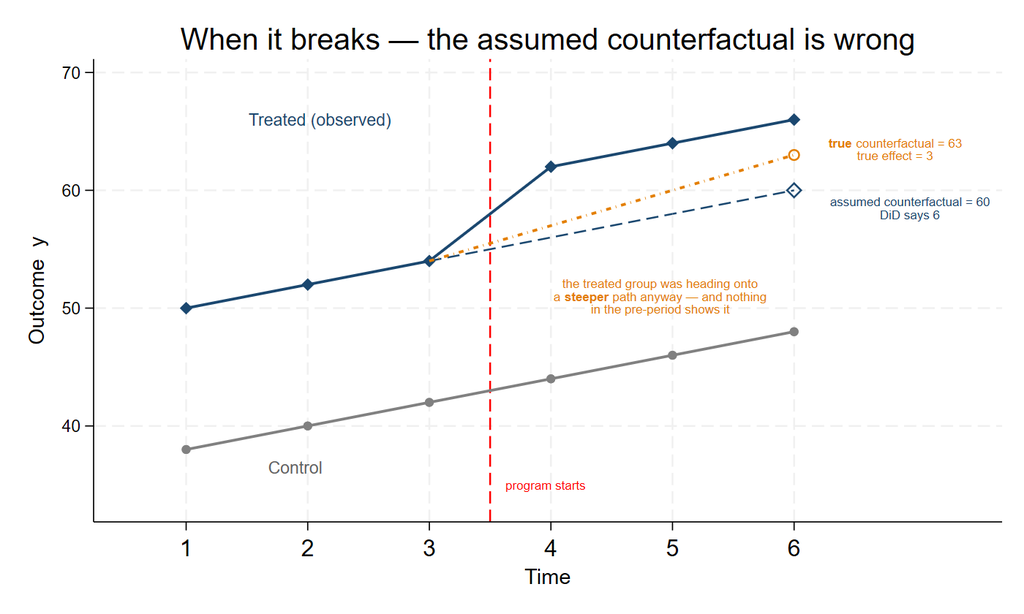

This broken world and the good one look **identical before the program**.

Flat pre-trends are supporting evidence, not proof.

*Remember this — it is today’s key idea.*

# Question 4 — the mechanics

- The 2×2 estimate is the interaction coefficient in `reg y i.treated##i.post` — four means with a standard error.
- Cluster at the level at which **treatment was assigned**: the district.

**Today’s question:** on Day 1 the map had a single red “program starts” line. Today every cohort has its own.

**What happens to the map — and who, exactly, is the control group?**

# Part 1 — The obvious thing, and what it returns

# Load Day 1’s panel

```stata
use "${der}/day1_panel.dta", clear
xtset district_id year
gen byte treat = (year >= adopt_year) & !missing(adopt_year)
```

- Same panel as Day 1 — nothing to rebuild.
- One new variable: `treat` switches on at **each district’s own** adoption year. That one line is the whole generalization.

# Where we left off

Day 1: 2007 cohort vs never-treated — clean event study, flat pre-trends, effect growing to ~9.5 points.

But we threw away three quarters of the data.

```stata
table (adopt_year) if year == 2019, stat(freq)
```

```
adopt_year |
  2007     |     45
  2010     |     45
  2013     |     45
  2016     |     30
      .    |     15
```

**Staggered adoption** — the most common setting in real policy work.

# All five groups

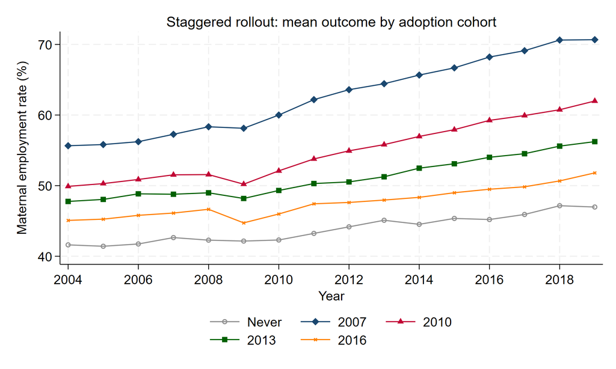

# The obvious generalization

Day 1’s regression never mentioned a start date:

$$y_{it} = \alpha_i + \lambda_t + \beta D_{it} + \varepsilon_{it}$$

$D_{it}$ just switches on when district $i$ adopts.

So do what almost every paper did from 1994 to ~2018 — run it on the full panel:

```stata
areg emp_rate treat i.year, absorb(district_id) cluster(district_id)
```

# The result

```
       treat |   .1024949   .1858339     0.55   0.582
```

0.10 points. p = 0.58.

On Day 1, a quarter of this data gave **5.59, highly significant**.

With four times the data, the effect has vanished.

Something is wrong. The question is what.

# Build the event-study dummies

Same trick as Day 1 — two changes: `rel` now exists for **every** adopting district, and the leads run the full −12 … −2.

```stata
gen rel = year - adopt_year

forvalues k = 12(-1)2 {
    qui gen byte lead_`k' = (rel == -`k') & !missing(rel)
}
forvalues k = 0/12 {
    qui gen byte lag_`k'  = (rel ==  `k') & !missing(rel)
}
```

(Leave leads out and they quietly join the comparison group — biasing everything.)

# Check the assumption — the way we learned on Day 1

```stata
areg emp_rate lead_* lag_* i.year, ///
    absorb(district_id) cluster(district_id)
```

```
   k = -12   coef =   1.565   se = 0.326   p = 0.000   <-- significant
   k = - 9   coef =   1.177   se = 0.258   p = 0.000   <-- significant
   k = - 5   coef =   1.032   se = 0.205   p = 0.000   <-- significant
   k = - 2   coef =   0.763   se = 0.195   p = 0.000   <-- significant
```

**Every one of the eleven pre-period coefficients is significant.**

# The picture

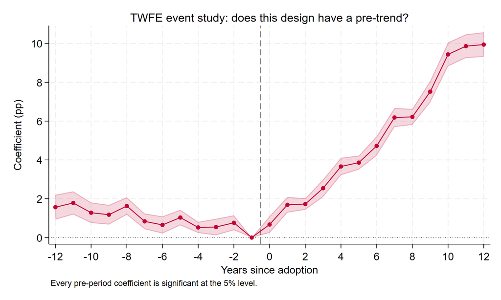

Treated districts *appear* to have been on a higher path for a decade before adopting anything.

# Before you see the next slide

Write down your answer.

You have: an estimate near zero, and an event study that fails the pre-trend check everywhere.

**What do you conclude, and what do you do next?**

*We move on when everyone has something on paper.*

# Part 2 — The reveal

# This data is simulated

We know the true effect for every district in every year — it was written into the data before anything was estimated.

```
  TRUE average treatment effect on the treated :  3.946
  Pre-period observations with a non-zero effect:    0
```

- **The program worked: 3.95 points.** The static regression said 0.10 — about 2.6% of the truth.
- **Parallel trends holds exactly** — zero pre-period effects anywhere. The pre-trend you found does not exist.

# What is actually in the data

```
 adopt_year |   Mean tau
  2007      |    5.885
  2010      |    3.575
  2013      |    2.000
  2016      |    1.000
```

Two things, both true of most real rollouts:

1. **Effects grow over time** — capacity takes years to build.
2. **Cohorts differ** — early adopters gain more.

Both are normal. Neither breaks parallel trends.

> **The lesson: the estimator was broken — and so was the test you used to check it. Both pointed at the same wrong conclusion.**

# Why it breaks: Goodman-Bacon (2021)

The static TWFE estimate is a **weighted average of every possible 2×2** in the data.

It needs a **balanced** panel — drop districts with gaps, and say so:

```stata
bysort district_id: egen byte anymiss = max(missing(emp_rate))
keep if anymiss == 0
bacondecomp emp_rate treat, ddetail
```

```
  Districts dropped to balance the panel: 46 of 180
```

The estimate being decomposed is therefore 0.190, not 0.102.

# The decomposition

| Comparison type | Sign of every term | Weight | Legitimate? |
| --- | --- | --- | --- |
| `Never_v_timing` | **positive** (+2.77) | 22% | yes |
| `Early_v_Late` | **positive** (+0.88 to +4.19) | ~33% | yes |
| `Late_v_Early` | **negative** (−0.94 to −4.54) | **~45%** | **no** |

Nearly half the estimate comes from comparisons that should never happen — and they push the estimate down, nearly wiping out the real effect.

# Every 2×2, plotted

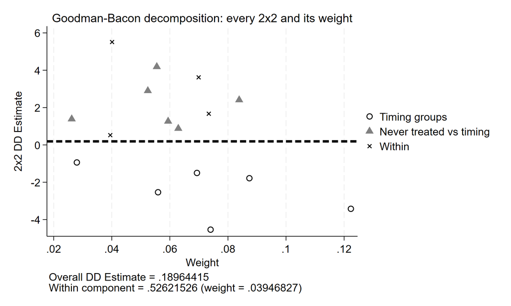

Above the dashed line: the legitimate comparisons. Below: already-treated districts used as controls — wrong sign, heavy weights.

The dashed line is their weighted average: **0.19 — next to nothing.**

# Why “already treated” controls are poison

Compare a 2013 adopter against a 2007 adopter: the 2007 district plays *control* — but its outcome is still **rising from its own treatment**.

Subtract one treated group’s rise from another’s, and you remove the very thing you are measuring.

Because effects grow, the “control” rises faster than the “treated” — and the comparison turns negative.

The same contamination created the fake pre-trend.

# Part 3 — Rebuilding the estimator

# By hand: Day 1’s 2×2, one cohort at a time

**Rule: never use an already-treated district as a control.**

$$\widehat{ATT}(g,t) = \big(\bar y_{g,t} - \bar y_{g,g-1}\big) - \big(\bar
y_{\text{never},t} - \bar y_{\text{never},g-1}\big)$$

A loop over cohorts and years; four sample means per cell; `post` the result.

# The loop

```stata
foreach g of local cohorts {
    forvalues t = `g'/`tmax' {
        local base = `g' - 1
        qui sum emp_rate if adopt_year == `g' & year == `t'
        local a1 = r(mean)                        // treated, after
        qui sum emp_rate if adopt_year == `g' & year == `base'
        local a0 = r(mean)                        // treated, before
        qui sum emp_rate if missing(adopt_year) & year == `t'
        local c1 = r(mean)                        // never-treated, after
        qui sum emp_rate if missing(adopt_year) & year == `base'
        local c0 = r(mean)                        // never-treated, before
        post `M' (`g') (`t') ((`a1'-`a0')-(`c1'-`c0'))
    }
}
```

Four `sum`s per cell — the four means of a 2×2. Base year `g − 1`; controls **never-treated only**. (Abridged; full version in `day2.do`.)

# What the loop returns

```
  Hand-built overall ATT =  3.864   (truth:  3.946)

  | 2007     5.370      5.904 |
  | 2010     4.283      3.563 |
  | 2013     1.783      2.006 |
  | 2016     0.506      0.998 |
```

No package. Just sample means.

TWFE was off by a factor of forty; this simple loop lands within 0.1 of the truth — and ranks the cohorts correctly.

# Doing it properly: `csdid` (Callaway & Sant’Anna 2021)

```stata
gen gvar = cond(missing(adopt_year), 0, adopt_year)
csdid emp_rate, ivar(district_id) time(year) gvar(gvar) notyet
estat simple
```

```
         ATT |   3.951182   .2079284    19.00   0.000

  >>> TRUE ATT =  3.946
```

- `gvar()`: adoption cohort, 0 = never treated.
- `notyet`: not-yet-treated units may serve as controls — buys precision.
- What it will **never** do: use an already-treated unit as a control.

# The event study, done right

```stata
estat event, window(-8 12)
```

```
     Pre_avg |  -.0032269   .0321131    -0.10   0.920
    Post_avg |   5.203305   .1778835    29.25   0.000
```

Same data — and the pre-trend that was significant at every lead has **disappeared**.

Nothing about the districts changed. Only which comparisons the estimator was allowed to make.

# The picture

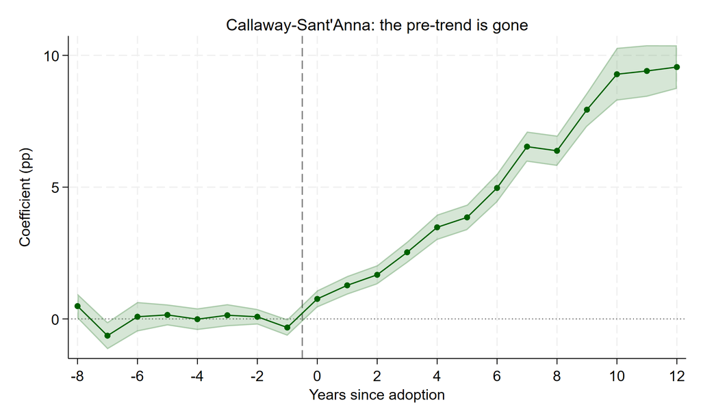

Honest caveat: `Tm8`, `Tm7`, `Tm1` are individually significant — eight tests, 15 never-treated districts, some come up by chance.

Roth (2022): don’t judge a design by individual leads — they are noisy, in both directions.

`Pre_avg` = −0.003 (p = 0.92) is the informative summary.

# Three estimators, one dataset

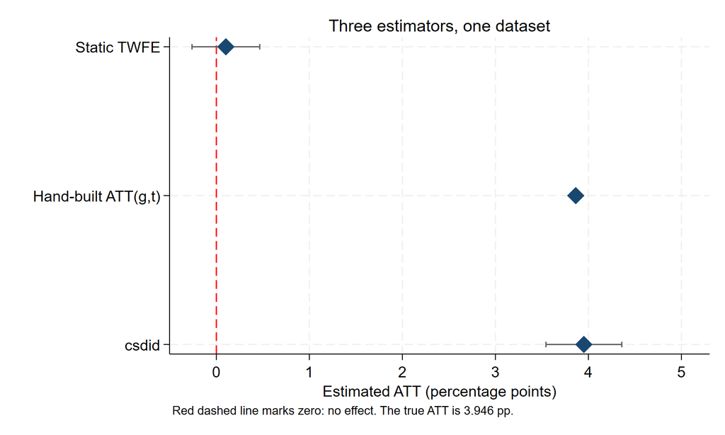

```
  |         Static TWFE   0.102   0.186 |
  | Hand-built ATT(g,t)   3.864       . |
  |               csdid   3.951   0.208 |
```

One question. Three answers. Two of them right.

# Part 4 — The table, regenerated

# Every number in Day 1’s table is now wrong

Headline 0.10 → 3.95; new estimator; new sample; new standard errors.

If Table 1 lived in Word, you would be retyping all of it tonight.

```stata
eststo d1: qui areg emp_rate treat i.year, ///
    absorb(district_id) cluster(district_id)
qui csdid emp_rate, ivar(district_id) time(year) ///
    gvar(gvar) notyet agg(simple)
eststo d2
qui csdid emp_rate, ivar(district_id) time(year) ///
    gvar(gvar) agg(simple)
eststo d3
```

Then Day 1’s pattern — one options macro, three outputs:

```stata
esttab d1 d2 d3, `topts'
esttab d1 d2 d3 using "${res}/table2_staggered.rtf", replace `topts' ///
    title("The childcare program under three estimators")
```

# The one thing that will trip you up

`csdid` + `estat simple` does **not** post estimates for `esttab`:

```
. esttab .
estimates __000002 not found
r(111);
```

This error is what pushes people into clumsy workarounds (`parmest`, matrices).

**You don’t need them. The fix is the `agg(simple)` option** — it stores the overall ATT like a normal regression result, so `eststo`/`esttab` just work.

The coefficient is named `ATT`, so `rename(treat DiD ATT DiD)` puts everything on one row — exactly Day 1’s trick.

# Table 2

```
                                (1)             (2)             (3)
----------------------------------------------------------------------
Childcare program             0.102           3.951***        4.010***
                            (0.186)         (0.208)         (0.241)
----------------------------------------------------------------------
Estimator               Static TWFE    Callaway-Sant'Anna  Callaway-Sant'Anna
Comparison group    All other districts   Not-yet-treated  Never-treated only
Observations                   2827            2782            2782
```

Columns 2 vs 3: `notyet` bought precision (0.208 vs 0.241) without costing accuracy — both bracket the truth.

Showing both is how you demonstrate the result does not depend on the choice.

# One command rebuilds everything

```stata
do master.do
```

- checks packages first (`csdid drdid bacondecomp estout`), fails loudly
- one `global root` — the only absolute path in the project
- rebuilds both days: data, seven figures, two tables, Word + LaTeX

> If reproducing your project means *remembering which files to run in which order*, you will eventually break it — usually when a referee asks for one more column.

# What changed, and when

# The history in one slide

- **Card & Krueger (1994):** one treated state, one control, one date. Day 1’s 2×2 was the complete, correct tool.
- **1994–2018:** the profession ran `areg y treat i.year, absorb(id)` on staggered rollouts and read $\beta$ as an average effect.
- **Goodman-Bacon (2021):** it usually isn’t one.

The modern literature is not a replacement for DiD.

It is the same idea, protected from the ways the simple version fails.

# The rule to leave with

> Units adopt at **different times** → do not report static TWFE as the headline. Use an estimator that respects who is a valid control.

> Units all adopt at the **same time** → Day 1’s method is still correct, and you need none of this.

| Problem | Tool |
| --- | --- |
| already-treated units as controls | `csdid`, `did_imputation`, `did2s` |
| contaminated event-study leads | `eventstudyinteract` (Sun & Abraham) |
| where did the weights go? | `bacondecomp` |
| pre-trend tests underpowered | Roth (2022) |
| parallel trends only *nearly* true | `honestdid` (Rambachan & Roth) |
| treatment turns on **and off** again | `did_multiplegt_dyn` (de Chaisemartin & D’Haultfœuille) |
| treatment is a **dose**, not on/off | Callaway, Goodman-Bacon & Sant’Anna |

# Where to read next

- **Roth (2022)**, *AER: Insights* — pre-trend testing. **Read this one first.**
- **Goodman-Bacon (2021)**, *J. Econometrics* — the decomposition you ran.
- **Callaway & Sant’Anna (2021)**, *J. Econometrics* — the estimator behind `csdid`.
- **Sun & Abraham (2021)**, *J. Econometrics* — contaminated leads.
- **Rambachan & Roth (2023)**, *REStud* — sensitivity analysis, not pre-testing.
- **de Chaisemartin & D’Haultfœuille**, *AER* (2020) + *REStat* (2024) — treatments that switch on **and off**, or change in steps (not just 0/1); their command is `did_multiplegt_dyn`.
- **Callaway, Goodman-Bacon & Sant’Anna**, *AER* (forthcoming) — DiD with a **continuous** treatment: a dose, not a switch.
- **Roth, Sant’Anna, Bilinski & Poe (2023)** — the survey; use its flowchart.

**You leave with the full project: data, do-files, handouts — a template to adapt to your own research. The assignment (next slides) uses it.**

# The assignment

# The exercises

Work in groups: one do-file per group, top to bottom, written answers in comments; submit the `.do` and its `.log` before you leave.

1. **Confirm the diagnosis.** Re-run the static TWFE using only the 2007 cohort and the never-treated districts. Compare it to Day 1’s 5.59 and to today’s 0.10. Which comparisons did dropping the other cohorts remove?
2. **Never-treated only.** Re-run `csdid` without the `notyet` option. Compare the point estimate and the standard error. What did `notyet` buy, and what did it cost?
3. **Report it.** Produce one table with all three of today’s estimates, plus the two-sentence caveat you would put under it in a policy brief for a ministry that has not read Goodman-Bacon.
4. **Break it, then fix it.** Build the Day 2 table using `estat simple` followed by `esttab .`, and confirm the `r(111)` error. Then fix it with `agg(simple)`. Better to meet this error today than at midnight.
5. **Run the whole thing** *(optional, for your own time)*. Delete everything in `output/`, run `master.do`, and confirm it all comes back identical. (Expected exception: `.rtf` files embed the time they were written.)